# Historical MAL dataset cleanup

Edward Yu

December 07, 2018

# Introduction

## *From Marek*:

### If you are interested I have a small project for R, which is very useful. It has to do with history records of MAL. Here is some basic info:

- Goal: Clean up and consolidate dataset to enable easy searching of past melt records
- Tasks:
  - Mostly working with strings removing duplicates ( E. Yu, YU, Yu Edward …)
  - Removing empty records
  - Missing data
  - Multiple variables in one column

There might be other things to do but I have not spent much time looking at the dataset. We could also pull some basic stats on usage, costs, repeats etc. I don’t know your skill level, but it is relatively simple project and I am estimating it would take me about 8 hrs of work. Actual coding, if you know what to use, could be done in less than 1 hour but that requires proficiency in typing and in R.

I just noticed that sand for this year should have all been W410, excel incremented the name by 1 each time. I think I might be adding information about individual tests from this year incrementally as it comes in and since it is only several rows, perhaps you can delete the entire set of rows from this year, if that makes things easier on your end.

# Load & peak data

## Import data

```r
x <- read_csv("data/History.csv")
glimpse(x)
```

```
## Observations: 3,629
## Variables: 19
## $ Request              <dbl> 1, 2, 3, 4, 5, 6, 7, 8, 9, 10, 11, 12, 13...
## $ ID                   <dbl> NA, NA, NA, NA, 12201, 12194, NA, NA, NA,...
## $ `Date  Poured`       <chr> "1/5/1999", "1/6/1999", "1/7/1999", "1/8/...
## $ `Date Received`      <chr> "1/4/1999", "1/4/1999", "1/4/1999", "1/4/...
## $ `Date Completed`     <chr> "1/13/1999", "1/13/1999", "1/13/1999", "1...
## $ `Requested by`       <chr> "18", "CLINGERMAN,M.", "CLINGERMAN, M.", ...
## $ `Customer Name`      <chr> "TS&D", "TS&D", "TS&D", "TS&D", "BRILLION...
## $ `Product Tested`     <chr> "ISOCURE", "ISOCURE", "ISOCURE", "ISOCURE...
## $ `Casting Type`       <chr> "STEPCONE", "STEPCONE", "EROSION WEDGE", ...
## $ `Number of castings` <dbl> 8, 8, 8, 8, 3, 1, 8, 10, 8, 4, 10, 8, 2, ...
## $ Alloy                <chr> "GRAY IRON", "GRAY IRON", "GRAY IRON", "G...
## $ lbs                  <dbl> 250, 250, 600, 600, 90, 90, 160, 30, 20, ...
## $ `Sand type`          <chr> "TECHNISAND 1L-5W", "TECHNISAND 1L-5W", "...
## $ `Amount used`        <dbl> 840, 840, 1680, 1680, 270, 210, 640, 240,...
## $ `Total hours`        <lgl> NA, NA, NA, NA, NA, NA, NA, NA, NA, NA, N...
## $ `Total Cost`         <dbl> 1300, 1300, 2210, 2210, 862, 715, 2080, 8...
## $ `Furnace Cycle`      <chr> "W68", "W69", "W70, W71", "W72, W73", "W7...
## $ `Notes ML`           <chr> "TEST NEW BASE RESIN WITH STEPCONE CASTIN...
## $ `Special Projects`   <chr> NA, NA, NA, NA, NA, NA, NA, NA, NA, NA, N...
```

## Check levels

```r
# create function for later use
get_levels <- function(df, col){
  x.levels <- cbind(colnames(df),
                    (as.data.frame(sapply(df,function(x) length(unique(x)))))
  )
  colnames(x.levels) <- c("var","levels")
  row.names(x.levels) <- NULL
  levels <- x.levels[order(-x.levels[,2]),]
  return(levels[col,])
}
get_levels(x)
```

|  | var | levels |
| --- | --- | --- |
| 1 | Request | 3628 |
| 18 | Notes ML | 2902 |
| 3 | Date Poured | 2746 |
| 5 | Date Completed | 1989 |
| 4 | Date Received | 1962 |
| 17 | Furnace Cycle | 1718 |
| 2 | ID | 1623 |
| 7 | Customer Name | 373 |
| 9 | Casting Type | 273 |
| 6 | Requested by | 259 |

[output cut: 9 more lines]

## Peak missing values

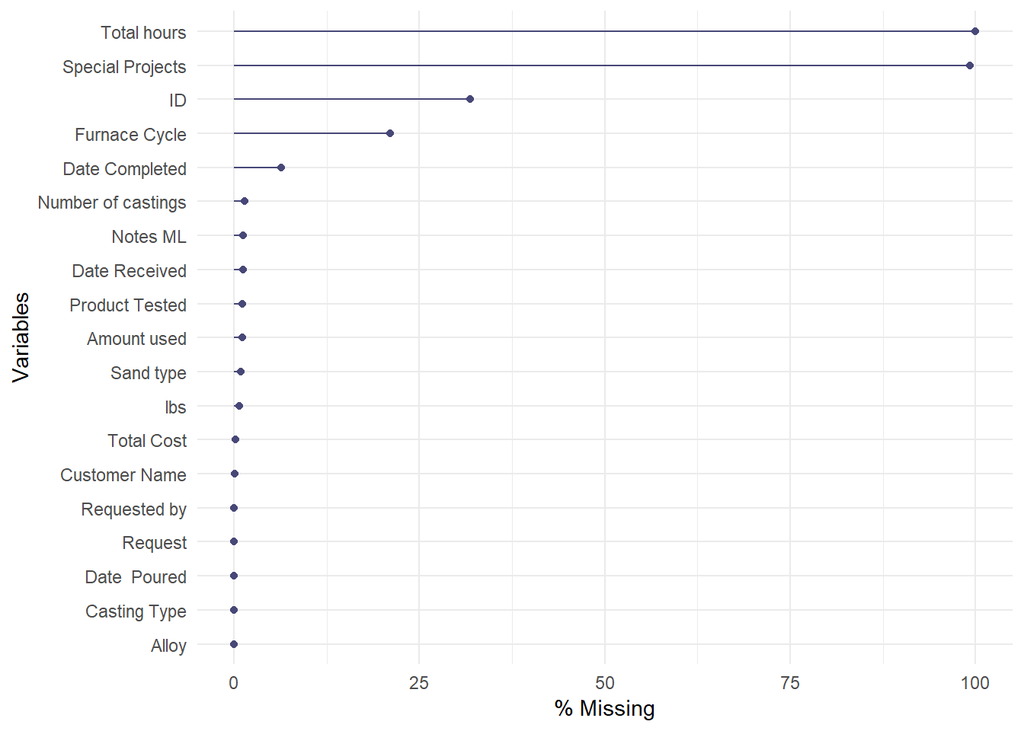

```r
gg_miss_var(x, show_pct = T)
```

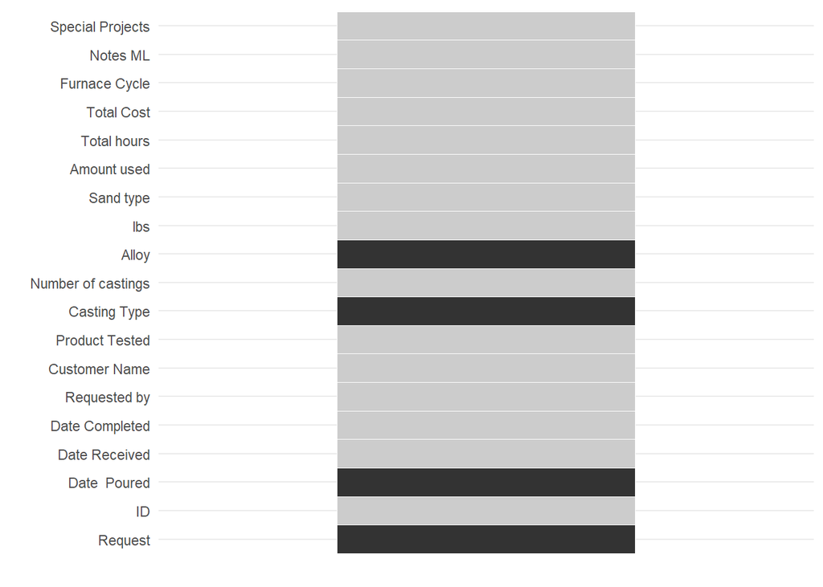

```r
gg_miss_which(x)
```

## Outline of actions to take

- **Request**: should have 3,629 levels
- **ID**: not utilized in recent pours, delete
- **Date received**: convert to date format, fill missing values, for some reason there are less dates received than dates completed
- **Date poured**: convert to date format, fill missing values
- **Date completed**: convert to date format, fill missing values, perhaps create new column calculating days to complete from date received/completed
- **Notes ML**: NA
- **Special projects**: most values are missing, unsure of importance of this field, should likely merge with comments or remove entirely
- **Requested by**: fill missing values, will require some renaming/matching
- **Customer name**: fill missing values, will require some renaming/matching
- **Product tested**: fill missing values, will require some renaming/matching
- **Alloy**: NA
- **Casting type**: NA
- **Number of castings**: some NA values, fill in with rounded averages
- **lbs**: lbs of metal used, could be calculated based on values, fill missing values
- **Sand type**: fill missing values, will require some renaming/matching
- **Amount used**: sand? unsure what amount this is talking about
- **Furnace cycle**: need to come up with new way to ID new lining and cycles
- **Total hours**: many NA values, should be calculated automatically based on number of castings, casting type, etc
- **Total cost**: fill missing values, perhaps determine how it is calculated to automate the calculation

We have many missing datapoints, fields that aren’t inuitive, some useless fields, fields that need added, etc. We’ll start with the most simple and move on.

# Cleaning

## Rename columns

Convert column names to lower case, replace spaces with periods.

```r
names <- tolower(colnames(x))    # convert to lowercase
names <- gsub("  ", " ", names)  # remove double spaces
names <- gsub(" ", "\\.", names) # replace space with .
names[c(12,14)] <- c("alloy.lbs", "sand.lbs")
colnames(x) <- names
colnames(x)
```

```
##  [1] "request"            "id"                 "date.poured"
##  [4] "date.received"      "date.completed"     "requested.by"
##  [7] "customer.name"      "product.tested"     "casting.type"
## [10] "number.of.castings" "alloy"              "alloy.lbs"
## [13] "sand.type"          "sand.lbs"           "total.hours"
## [16] "total.cost"         "furnace.cycle"      "notes.ml"
## [19] "special.projects"
```

## $request

There is a duplicate entry somewhere based on number of unique levels versus number of rows.

```r
which(duplicated(x$request)==TRUE)
```

```
## [1] 3611
```

```r
as.data.frame(t(x[3609:3611,]))
```

|  | V1 | V2 | V3 |
| --- | --- | --- | --- |
| request | 3609 | 3610 | 3610 |
| id | NA | NA | NA |
| date.poured | 9/13/2017 | unknown | 6/28/2018 |
| date.received | NA | NA | NA |
| date.completed | NA | NA | NA |
| requested.by | VIVAS | unknown | unknown |
| customer.name | ASK | unknown | ASK |
| product.tested | COATINGS | unknown | unknown |
| casting.type | STEP CONES | unknown | unknown |
| number.of.castings | NA | NA | NA |

[output cut: 9 more lines]

The first entry appears to have been made in error until we see the furnace cycle was incremented. Probably shouldn’t remove, will simply re-assign all request variables to equal row numbers.

```r
x <- x %>%
  mutate(request = seq(1:nrow(x)))
get_levels(x, 1)
```

|  | var | levels |
| --- | --- | --- |
| 1 | request | 3629 |

## $id

Delete useless column.

```r
x <- x %>%
  select(-id)
```

## Convert dates, add lead time

Convert char to date values.

```r
x <- x %>%
  mutate(date.poured = as.Date(x$date.poured, "%m/%d/%Y")) %>%
  mutate(date.received = as.Date(x$date.received, "%m/%d/%Y")) %>%
  mutate(date.completed = as.Date(x$date.completed, "%m/%d/%Y"))

summary(x[c(3,2,4)])
```

```
##  date.received         date.poured         date.completed
##  Min.   :1990-10-20   Min.   :1995-08-04   Min.   :1999-01-13
##  1st Qu.:2001-07-27   1st Qu.:2001-08-08   1st Qu.:2001-10-31
##  Median :2005-06-08   Median :2005-07-11   Median :2005-09-23
##  Mean   :2006-02-25   Mean   :2006-03-03   Mean   :2006-04-11
##  3rd Qu.:2010-03-31   3rd Qu.:2010-05-18   3rd Qu.:2010-06-11
##  Max.   :2513-11-01   Max.   :2078-08-24   Max.   :2106-04-05
##  NA's   :43           NA's   :1            NA's   :229
```

With these dates we can now determine a few useful values:

- Preprocessing time: date poured - date recieved
- Postprocessing time: date complete - date poured
- Lead time: date complete - date received

Of course, we need to fix the erroneous entries that are pushing our `Max` values all the way up to the year 2513.

### Fix far future dates

We manually fix the handful of dates with typos.

```r
wrong.dates <- x %>%
  filter(date.received  > "2020-01-01" |
         date.poured    > "2020-01-01" |
         date.completed > "2020-01-01")
as.data.frame(wrong.dates)[,c(1,3,2,4)]
```

| request | date.received | date.poured | date.completed |
| --- | --- | --- | --- |
| 1103 | 2002-04-12 | 2020-04-30 | 2002-05-03 |
| 1198 | 2002-07-02 | 2002-08-02 | 2020-08-22 |
| 1889 | 2021-11-17 | 2005-11-21 | 2005-11-23 |
| 2735 | 2010-06-04 | 2020-06-10 | 2010-06-11 |
| 2740 | 2021-06-15 | 2010-06-21 | 2010-06-22 |
| 3106 | 2021-03-20 | 2012-03-21 | 2012-03-22 |
| 3149 | 2023-06-19 | 2012-06-26 | 2012-06-27 |
| 3341 | 2513-11-01 | 2013-11-22 | 2013-12-02 |
| 3582 | 2016-03-16 | 2016-04-01 | 2106-04-05 |
| 3606 |  | 2078-08-24 |  |

```r
# manually fix
x$date.poured[1103]    <- as.Date("2002-04-30")
x$date.completed[1198] <- as.Date("2002-08-22")
x$date.received[1889]  <- as.Date("2005-11-17")
x$date.poured[2735]    <- as.Date("2002-06-10")
x$date.received[2740]  <- as.Date("2010-06-15")
x$date.received[3106]  <- as.Date("2012-03-20")
x$date.received[3149]  <- as.Date("2012-06-19")
x$date.received[3341]  <- as.Date("2013-11-01")
x$date.completed[3582] <- as.Date("2016-04-05")
x$date.poured[3606]    <- as.Date("2017-08-24")

# dates now seem to be in a normal range
summary(x[c(3,2,4)])
```

```
##  date.received         date.poured         date.completed
##  Min.   :1990-10-20   Min.   :1995-08-04   Min.   :1999-01-13
##  1st Qu.:2001-07-27   1st Qu.:2001-08-08   1st Qu.:2001-10-31
##  Median :2005-06-08   Median :2005-07-07   Median :2005-09-20
##  Mean   :2005-12-31   Mean   :2006-02-21   Mean   :2006-03-30
##  3rd Qu.:2010-03-30   3rd Qu.:2010-05-17   3rd Qu.:2010-06-10
##  Max.   :2016-04-25   Max.   :2018-11-28   Max.   :2016-05-02
##  NA's   :43           NA's   :1            NA's   :229
```

### Calculate lead times

Now that are values are all within somewhat normal ranges, detecting further errors will require calculating the differences in dates. For example if `date.received` has a later date than `date.completed` we will see a negative value in our new `lead.time` variable.

Using the function on our current data shows negative values in all new variables as well as some unrealistically large `Max` values.

```r
## create function so that results of editing can be seen quickly
calc_lead <- function(){
  preprocessing.time  <- as.numeric(x$date.poured-x$date.received)
  postprocessing.time <- as.numeric(x$date.completed-x$date.poured)
  lead.time           <- preprocessing.time + postprocessing.time
  x.temp <- as_tibble(cbind(x,
                            preprocessing.time,
                            postprocessing.time,
                            lead.time))
  return(x.temp)
}

summary(calc_lead()[c(19:21)])
```

```
##  preprocessing.time postprocessing.time   lead.time
##  Min.   :-3288.00   Min.   :-4014.000   Min.   :-4011.000
##  1st Qu.:    3.00   1st Qu.:    1.000   1st Qu.:    5.000
##  Median :    5.00   Median :    2.000   Median :    8.000
##  Mean   :    5.74   Mean   :    3.641   Mean   :    8.176
##  3rd Qu.:    8.00   3rd Qu.:    5.000   3rd Qu.:   14.000
##  Max.   : 3293.00   Max.   : 3288.000   Max.   : 2804.000
##  NA's   :43         NA's   :229         NA's   :232
```

### Fix large processing values

We filter for values larger than 400 and find quite a few entries have simple typos. We correct the handful of errors by hand.

```r
## fix large values
wrong.dates <- calc_lead() %>%
  filter(preprocessing.time > 400 |
           postprocessing.time > 400)
wrong.dates[c(1,3,2,4)]
```

| request | date.received | date.poured | date.completed |
| --- | --- | --- | --- |
| 310 | 1990-10-20 | 1999-10-21 |  |
| 930 | 2001-08-24 | 2010-08-30 | 2001-09-04 |
| 1091 | 2002-04-09 | 2001-04-22 | 2002-07-12 |
| 1616 | 2000-04-13 | 2004-04-21 | 2004-04-26 |
| 1668 | 2004-08-04 | 1995-08-04 | 2004-08-04 |
| 1877 | 2005-10-31 | 2003-11-01 | 2005-11-14 |
| 2229 | 2000-01-07 | 2007-09-11 | 2007-09-11 |
| 2735 | 2010-06-04 | 2002-06-10 | 2010-06-11 |
| 3133 | 2012-05-16 | 2010-05-17 | 2012-05-18 |

```r
# manually fix
x$date.received[310]  <- as.Date("1999-10-20")
x$date.poured[930]    <- as.Date("2001-08-30")
x$date.poured[1091]   <- as.Date("2002-04-22")
x$date.received[1616] <- as.Date("2004-04-13")
x$date.poured[1668]   <- as.Date("2004-08-04")
x$date.poured[1877]   <- as.Date("2005-11-01")
x$date.received[2229] <- as.Date("2007-01-07")
x$date.poured[2735]   <- as.Date("2010-06-10")
x$date.poured[3133]   <- as.Date("2012-05-17")

# max values look better now
summary(calc_lead()[c(19:21)])
```

```
##  preprocessing.time  postprocessing.time   lead.time
##  Min.   :-3283.000   Min.   :-4014.000   Min.   :-4011.000
##  1st Qu.:    3.000   1st Qu.:    1.000   1st Qu.:    5.000
##  Median :    5.000   Median :    2.000   Median :    8.000
##  Mean   :    5.028   Mean   :    2.244   Mean   :    6.993
##  3rd Qu.:    8.000   3rd Qu.:    5.000   3rd Qu.:   14.000
##  Max.   :  374.000   Max.   :  383.000   Max.   :  434.000
##  NA's   :43          NA's   :229         NA's   :232
```

### Fix negative processing values

This occurs when dates are not in proper chronology: date.received < date.poured < date.completed. We can fix this by filtering for dates that do not meet this criteria and adjusting them based on available dates and median values for preprocessing/postprocessing/lead times.

In this case we have 244 rows of incorrectly ordered data, definitely not going to do this manually. This time we’ll impute the missing data by taking the median values of the correct data. First part of the code fixes NA values.

```r
# fix negatives
# must follow: received < poured < completed
wrong.dates2 <- calc_lead() %>%
  filter(preprocessing.time < 0 | postprocessing.time < 0)
wrong.dates2[c(1,3,2,4)]
```

| request | date.received | date.poured | date.completed |
| --- | --- | --- | --- |
| 13 | 1999-01-15 | 1999-01-19 | 1999-01-17 |
| 40 | 1999-02-27 | 1999-02-23 | 1999-02-24 |
| 41 | 1999-02-27 | 1999-02-24 | 1999-02-25 |
| 191 | 1999-07-06 | 1999-07-08 | 1999-06-29 |
| 314 | 1999-10-26 | 1999-10-27 | 1999-10-26 |
| 398 | 2000-12-22 | 2000-01-26 |  |
| 424 | 2000-03-10 | 2000-02-16 | 2000-02-24 |
| 448 | 2000-03-06 | 2000-03-10 | 2000-03-06 |
| 457 | 2000-03-17 | 2000-03-20 | 2000-03-18 |
| 458 | 2000-03-16 | 2000-03-21 | 2000-03-17 |

[output cut: 234 more lines]

```r
# antijoin the incorrect data
x.anti <- anti_join(calc_lead(), wrong.dates2, c("request"))

# record median values for imputation
summary(x.anti[c(19:21)])
```

```
##  preprocessing.time postprocessing.time   lead.time
##  Min.   :  0.000    Min.   :  0.000     Min.   :  0.00
##  1st Qu.:  3.000    1st Qu.:  1.000     1st Qu.:  6.00
##  Median :  6.000    Median :  3.000     Median :  9.00
##  Mean   :  8.141    Mean   :  5.218     Mean   : 13.11
##  3rd Qu.:  8.000    3rd Qu.:  6.000     3rd Qu.: 14.00
##  Max.   :372.000    Max.   :308.000     Max.   :434.00
##  NA's   :43         NA's   :225         NA's   :228
```

```r
# preprocessing.time postprocessing.time   lead.time
# Median :  6.000    Median :  3.000     Median :  9.00

# have NA values in date.completed
summary(wrong.dates2[c(3,2,4)])
```

```
##  date.received         date.poured         date.completed
##  Min.   :1999-01-15   Min.   :1999-01-19   Min.   :1999-01-17
##  1st Qu.:2012-07-27   1st Qu.:2012-09-24   1st Qu.:2012-10-07
##  Median :2013-12-25   Median :2013-12-18   Median :2013-12-26
##  Mean   :2012-03-08   Mean   :2012-01-30   Mean   :2012-01-29
##  3rd Qu.:2014-10-15   3rd Qu.:2014-10-10   3rd Qu.:2014-10-11
##  Max.   :2016-02-24   Max.   :2016-02-25   Max.   :2016-02-24
##                                            NA's   :4
```

```r
# if NA change completed date to received + 9
for (i in 1:dim(wrong.dates2)[1]){
  if (is.na(wrong.dates2$date.completed[[i]]) == TRUE){
    wrong.dates2$date.completed[[i]] <- wrong.dates2$date.received[[i]] + 9
  }
}

# no more NA's
summary(wrong.dates2[c(3,2,4)])
```

```
##  date.received         date.poured         date.completed
##  Min.   :1999-01-15   Min.   :1999-01-19   Min.   :1999-01-17
##  1st Qu.:2012-07-27   1st Qu.:2012-09-24   1st Qu.:2012-07-24
##  Median :2013-12-25   Median :2013-12-18   Median :2013-12-22
##  Mean   :2012-03-08   Mean   :2012-01-30   Mean   :2011-12-27
##  3rd Qu.:2014-10-15   3rd Qu.:2014-10-10   3rd Qu.:2014-10-11
##  Max.   :2016-02-24   Max.   :2016-02-25   Max.   :2016-02-24
```

```r
#
# now we fix errors in chronology causing negative time calculations
summary(wrong.dates2[c(19:21)])
```

```
##  preprocessing.time postprocessing.time   lead.time
##  Min.   :-3283.00   Min.   :-4014.00    Min.   :-4011.00
##  1st Qu.:  -13.00   1st Qu.:    0.00    1st Qu.:  -12.00
##  Median :   -7.00   Median :    1.00    Median :   -5.00
##  Mean   :  -37.62   Mean   :  -36.91    Mean   :  -73.52
##  3rd Qu.:   -1.00   3rd Qu.:    3.00    3rd Qu.:    0.00
##  Max.   :  374.00   Max.   :  383.00    Max.   :   27.00
##                     NA's   :4           NA's   :4
```

```r
# start with received coming before poured
# wrong.dates2$date.received > wrong.dates2$date.poured
wrong.dates2[c(2,3,6,7),c(3,2,4)]
```

| date.received | date.poured | date.completed |
| --- | --- | --- |
| 1999-02-27 | 1999-02-23 | 1999-02-24 |
| 1999-02-27 | 1999-02-24 | 1999-02-25 |
| 2000-12-22 | 2000-01-26 | 2000-12-31 |
| 2000-03-10 | 2000-02-16 | 2000-02-24 |

```r
# then completed coming before poured
# wrong.dates2$date.poured > wrong.dates2$date.completed
# wrong.dates2$date.completed < wrong.dates2$date.poured
wrong.dates2[c(1,4,5,8),c(3,2,4)]
```

| date.received | date.poured | date.completed |
| --- | --- | --- |
| 1999-01-15 | 1999-01-19 | 1999-01-17 |
| 1999-07-06 | 1999-07-08 | 1999-06-29 |
| 1999-10-26 | 1999-10-27 | 1999-10-26 |
| 2000-03-06 | 2000-03-10 | 2000-03-06 |

```r
for (i in 1:dim(wrong.dates2)[1]){
  # preprocessing time = poured - received; median = 6
  if (wrong.dates2$date.received[[i]] > wrong.dates2$date.poured[[i]]){
    wrong.dates2$date.received[[i]] <- wrong.dates2$date.poured[[i]] - 6
  }
  # postprocessing time = completed - poured; median = 3
  if (wrong.dates2$date.completed[[i]] < wrong.dates2$date.poured[[i]]){
    wrong.dates2$date.completed[[i]] <- wrong.dates2$date.poured[[i]] + 3
  }
}

# confirm chronology
# wrong.dates2$date.received <= wrong.dates2$date.poured
# wrong.dates2$date.poured <= wrong.dates2$date.completed

# now that `wrong.dates2` has corrected values, merge with original df
counter=1
for (i in 1:nrow(x)){
  if (counter == nrow(wrong.dates)+1){break}
  if (x$request[[i]] == wrong.dates$request[[counter]]){
    x[i,c(2,3,4)] <- wrong.dates[counter,c(2,3,4)]
    counter=counter+1
  }
}

# date summary looks okay now... except for NA's
summary(calc_lead()[c(19:21)])
```

```
##  preprocessing.time postprocessing.time   lead.time
##  Min.   :-3288.00   Min.   :-4014.000   Min.   :-4011.000
##  1st Qu.:    3.00   1st Qu.:    1.000   1st Qu.:    5.000
##  Median :    5.00   Median :    2.000   Median :    8.000
##  Mean   :    5.74   Mean   :    3.641   Mean   :    8.176
##  3rd Qu.:    8.00   3rd Qu.:    5.000   3rd Qu.:   14.000
##  Max.   : 3293.00   Max.   : 3288.000   Max.   : 2804.000
##  NA's   :43         NA's   :229         NA's   :232
```

### Fix NA values in dates

Our calculations have NA values which means our dates must have NA’s. We’ll check which date columns contain NA’s and in a similar fashion to above will impute appropriate dates based on the calculated median values above.

Based on the `summary` output it looks like `date.poured` has only a single `NA` value. If we fill this date in by hand we can just calculate the other variables based on the `date.poured` value and our previously calculated median values of processing times.

```r
# check NAs
summary(x)[,c(3,2,4)]
```

```
##  date.received         date.poured         date.completed
##  Min.   :1990-10-20   Min.   :1995-08-04   Min.   :1999-01-13
##  1st Qu.:2001-07-27   1st Qu.:2001-08-08   1st Qu.:2001-10-31
##  Median :2005-06-08   Median :2005-07-07   Median :2005-09-20
##  Mean   :2005-12-31   Mean   :2006-02-21   Mean   :2006-03-30
##  3rd Qu.:2010-03-30   3rd Qu.:2010-05-17   3rd Qu.:2010-06-10
##  Max.   :2016-04-25   Max.   :2018-11-28   Max.   :2016-05-02
##  NA's   :43           NA's   :1            NA's   :229
```

```r
# fill NA values using date.poured to calculate received and completed
# guess on single NA
x %>% filter(is.na(date.poured))
```

| request | date.poured | date.received | date.completed | requested.by | customer.name | product.tested | casting.type | number.of.castings | alloy | alloy.lbs | sand.type | sand.lbs | total.hours | total.cost | furnace.cycle | notes.ml | special.projects |
| --- | --- | --- | --- | --- | --- | --- | --- | --- | --- | --- | --- | --- | --- | --- | --- | --- | --- |
| 3610 |  |  |  | unknown | unknown | unknown | unknown | NA | unknown | NA | unknown | NA | NA | NA | S2 | NA | NA |

```r
(x[3608:3612,])
```

| request | date.poured | date.received | date.completed | requested.by | customer.name | product.tested | casting.type | number.of.castings | alloy | alloy.lbs | sand.type | sand.lbs | total.hours | total.cost | furnace.cycle | notes.ml | special.projects |
| --- | --- | --- | --- | --- | --- | --- | --- | --- | --- | --- | --- | --- | --- | --- | --- | --- | --- |
| 3608 | 2017-09-08 |  |  | NOCERA | ASK | NA | EROSION WEDGE | NA | GRAY IRON | NA | NA | NA | NA | 0 | Q23 | NA | NA |
| 3609 | 2017-09-13 |  |  | VIVAS | ASK | COATINGS | STEP CONES | NA | GRAY IRON | NA | NA | NA | NA | 0 | S1 | NA | NA |
| 3610 |  |  |  | unknown | unknown | unknown | unknown | NA | unknown | NA | unknown | NA | NA | NA | S2 | NA | NA |
| 3611 | 2018-06-28 |  |  | unknown | ASK | unknown | unknown | NA | Aluminum | NA | W410 | NA | NA | 0 | S3 | NA | NA |
| 3612 | 2018-06-28 |  |  | Edward Yu | ASK | SLEEVES | Shrink Cubes | 8 | Steel | NA | W411 | NA | NA | NA | S4 | NA | NA |

```r
(x$date.poured[3611] - x$date.poured[3609]) / 2 # 144 days between dates
```

```
## Time difference of 144 days
```

```r
# just assign the middle date
x$date.poured[3610] <- x$date.poured[3609] - 72

# now date.poured has no NA's and we can extrapolate from this
summary(x)[,c(3,2,4)]
```

```
##  date.received         date.poured         date.completed
##  Min.   :1990-10-20   Min.   :1995-08-04   Min.   :1999-01-13
##  1st Qu.:2001-07-27   1st Qu.:2001-08-08   1st Qu.:2001-10-31
##  Median :2005-06-08   Median :2005-07-08   Median :2005-09-20
##  Mean   :2005-12-31   Mean   :2006-02-22   Mean   :2006-03-30
##  3rd Qu.:2010-03-30   3rd Qu.:2010-05-17   3rd Qu.:2010-06-10
##  Max.   :2016-04-25   Max.   :2018-11-28   Max.   :2016-05-02
##  NA's   :43                                NA's   :229
```

```r
# convert all NA date.received to date.poured-6
x.rec <- x %>%
  filter(is.na(date.received)) %>%
  mutate(date.received = date.poured - 6)

# merge back into original df
counter=1
for (i in 1:nrow(x)){
  if (x$request[[i]] == x.rec$request[[counter]]){
    x[i,c(2,3,4)] <- x.rec[counter,c(2,3,4)]
    counter=counter+1
  }
}

# convert all NA date.completed to date.poured+6
x.com <- x %>%
  filter(is.na(date.completed)) %>%
  mutate(date.completed = date.poured + 3)

# merge back into original df
counter=1
for (i in 1:nrow(x)){
  if (x$request[[i]] == x.com$request[[counter]]){
    x[i,c(2,3,4)] <- x.com[counter,c(2,3,4)]
    counter=counter+1
  }
}

# NOW we have zero NA values
summary(calc_lead()[c(19:21)])
```

```
##  preprocessing.time  postprocessing.time   lead.time
##  Min.   :-3288.000   Min.   :-4014.000   Min.   :-4011.000
##  1st Qu.:    3.000   1st Qu.:    1.000   1st Qu.:    5.000
##  Median :    5.000   Median :    3.000   Median :    8.000
##  Mean   :    5.743   Mean   :    3.601   Mean   :    9.344
##  3rd Qu.:    8.000   3rd Qu.:    5.000   3rd Qu.:   14.000
##  Max.   : 3293.000   Max.   : 3288.000   Max.   : 3291.000
```

```r
# assign our new values to the df
x <- calc_lead()
```

## $special.projects

Seems to be a redundant column when the $notes column would suffice. Check if values are stored in the column and concatenate them with the notes column.

```r
# list non-NA values in special projects
x$special.projects[!is.na(x$special.projects)]
```

```
##  [1] "RESIN"
##  [2] "RESIN"
##  [3] "RESIN"
##  [4] "RESIN"
##  [5] "RESIN"
##  [6] "RESIN"
##  [7] "G"
##  [8] "RAW 3114."
##  [9] "ROTORS FOR GILSON"
## [10] "ROTORS FOR R.SHOWMAN"
## [11] "ROTORS FOR R. SHOWMAN-ADD. HEAD HEIGHT"
## [12] "ROTOR D.O.E. R. SHOWMAN"
## [13] "ROTOR D.O.E. R. SHOWMAN"
## [14] "COPPER STEPCONES-FALCON FOUNDRY"
## [15] "COPPER STEPCONES-FALCON FOUNDRY"
## [16] "COPPER STEPCONES-FALCON FOUNDRY"
## [17] "HEAT EXCHANGER"
## [18] "Belt Buckels"
## [19] "BELT BUCKELS"
## [20] "ADDITIONAL METAL FOR 300 LBS."
## [21] "\\"
## [22] "'"
## [23] "'"
## [24] "SEE IF .5MM SILICA BEADS HAVE A BENEFIT"
## [25] "COATINGS AND ADDITIVES, PRODUCT SUPPORT"
## [26] "Coatings and Additives, Product Support"
## [27] "double height risers for penetration"
```

```r
# find rownums of non-NA vlaues
spec.rows <- which(!is.na(x$special.projects)==T)

# check notes.ml of same rownums
x$notes.ml[spec.rows]
```

```
##  [1] "DETERMINE EROSION (REVERSE SPRUE) OF 450WB/850WB-EXP. BASE"
##  [2] "DETERMINE EROSION (REVERSE SPRUE) OF 450WB/850WB"
##  [3] "DETERMINE EROSION (REVERSE SPRUE) OF 450WB/850WB BASE"
##  [4] "DETERMINE EROSION (REVERSE SPRUE) OF 450WB/850WB BASE"
##  [5] "COMPARE EROSION(REVERSE SPRUE) OF 450WB/850WB  W/EXP.BASE"
##  [6] "COMPARE EROSION(REVERSE SPRUE) OF 450WB/850WB EXP. BASE"
##  [7] "COMPARE SHAKEOUT OF EXISTING BINDER SYSTEMS FOR SALES MEETIN"
##  [8] "EVALUATE ISOSET BINDERS ON CUSTOMERS SAND TO REPLACE INSTAD"
##  [9] "MAKE AND SHIP ROTORS TO SHIN-KEN FOR D. GILSON"
## [10] "EVALUATE LARGER (50%) ROTOR CORE FOR VEINING"
## [11] "DOUBLE STACK ROTOR & ADD HEAD HEIGHT FOR VEINING."
## [12] "ROTOR D.O.E. TO EVALUATE VEINING, PENETRATION, &  SUR.FINISH"
## [13] "ROTOR D.O.E. TO EVALUATE VEINING, PENETRATION, & SUR. FINISH"
## [14] "FIND ONE BINDER SYSTEM TO WORK IN A COPPER BASE ALLOY"
## [15] "FIND ONE BINDER SYSTEM TO WORK IN A COPPER BASE ALLOY"
## [16] "FIND ONE BINDER SYSTEM TO WORK IN A COPPER BASE ALLOY"
## [17] "REPLACE HEAT EXCHANGER ON POWER TRACK"
## [18] "TEST DEFINITION OF BELT BUCKLE PATTERN"
## [19] "POUR BELT BUCKLES FOR SEMINAR GIFTS"
## [20] "DETERMINE AN ADDITIVE FOR USE WITH WARM BOX RESIN"
## [21] "INVESTIGATE NEW ISOCOTE SGW 32 VARIAITION-STEPCONE CST."
## [22] "EVALUATE DILATION, PENETRATION, VEINING, AND SURFACE FINISH"
## [23] "TEST MIRATEC TS 505 AND FORMULATION VARIATIONS"
## [24] "DETERMINE AFFECRS THAT ACTIVE CARBON PLAYS AS AN ADDITIVE"
## [25] "TEST MODIFICATIONS MADE TO MIRATEC 508"
## [26] "Test modifications made to MIRATEC MB 508"
## [27] NA
```

```r
# concatenate the columns
x[spec.rows,] <- x[spec.rows,] %>%
  mutate(notes.ml = paste(notes.ml, special.projects, sep="--"))

# confirm
x$notes.ml[spec.rows]
```

```
##  [1] "DETERMINE EROSION (REVERSE SPRUE) OF 450WB/850WB-EXP. BASE--RESIN"
##  [2] "DETERMINE EROSION (REVERSE SPRUE) OF 450WB/850WB--RESIN"
##  [3] "DETERMINE EROSION (REVERSE SPRUE) OF 450WB/850WB BASE--RESIN"
##  [4] "DETERMINE EROSION (REVERSE SPRUE) OF 450WB/850WB BASE--RESIN"
##  [5] "COMPARE EROSION(REVERSE SPRUE) OF 450WB/850WB  W/EXP.BASE--RESIN"
##  [6] "COMPARE EROSION(REVERSE SPRUE) OF 450WB/850WB EXP. BASE--RESIN"
##  [7] "COMPARE SHAKEOUT OF EXISTING BINDER SYSTEMS FOR SALES MEETIN--G"
##  [8] "EVALUATE ISOSET BINDERS ON CUSTOMERS SAND TO REPLACE INSTAD--RAW 3114."
##  [9] "MAKE AND SHIP ROTORS TO SHIN-KEN FOR D. GILSON--ROTORS FOR GILSON"
## [10] "EVALUATE LARGER (50%) ROTOR CORE FOR VEINING--ROTORS FOR R.SHOWMAN"
## [11] "DOUBLE STACK ROTOR & ADD HEAD HEIGHT FOR VEINING.--ROTORS FOR R. SHOWMAN-ADD. HEAD HEIGHT"
## [12] "ROTOR D.O.E. TO EVALUATE VEINING, PENETRATION, &  SUR.FINISH--ROTOR D.O.E. R. SHOWMAN"
## [13] "ROTOR D.O.E. TO EVALUATE VEINING, PENETRATION, & SUR. FINISH--ROTOR D.O.E. R. SHOWMAN"
## [14] "FIND ONE BINDER SYSTEM TO WORK IN A COPPER BASE ALLOY--COPPER STEPCONES-FALCON FOUNDRY"
## [15] "FIND ONE BINDER SYSTEM TO WORK IN A COPPER BASE ALLOY--COPPER STEPCONES-FALCON FOUNDRY"
## [16] "FIND ONE BINDER SYSTEM TO WORK IN A COPPER BASE ALLOY--COPPER STEPCONES-FALCON FOUNDRY"
## [17] "REPLACE HEAT EXCHANGER ON POWER TRACK--HEAT EXCHANGER"
## [18] "TEST DEFINITION OF BELT BUCKLE PATTERN--Belt Buckels"
## [19] "POUR BELT BUCKLES FOR SEMINAR GIFTS--BELT BUCKELS"
## [20] "DETERMINE AN ADDITIVE FOR USE WITH WARM BOX RESIN--ADDITIONAL METAL FOR 300 LBS."
## [21] "INVESTIGATE NEW ISOCOTE SGW 32 VARIAITION-STEPCONE CST.--\\"
## [22] "EVALUATE DILATION, PENETRATION, VEINING, AND SURFACE FINISH--'"
## [23] "TEST MIRATEC TS 505 AND FORMULATION VARIATIONS--'"
## [24] "DETERMINE AFFECRS THAT ACTIVE CARBON PLAYS AS AN ADDITIVE--SEE IF .5MM SILICA BEADS HAVE A BENEFIT"
## [25] "TEST MODIFICATIONS MADE TO MIRATEC 508--COATINGS AND ADDITIVES, PRODUCT SUPPORT"
## [26] "Test modifications made to MIRATEC MB 508--Coatings and Additives, Product Support"
## [27] "NA--double height risers for penetration"
```

## $requested.by

Remove duplicate and misspelled names.

```r
# remove double spaces, commas, periods, caps, generate soundex
x <- x %>%
  mutate(requested.by = str_replace_all(requested.by, '\\  ', '')) %>%
  mutate(requested.by = str_replace_all(requested.by, '\\,', '')) %>%
  mutate(requested.by = str_replace_all(requested.by, '\\.', '')) %>%
  mutate(requested.by = str_to_lower(requested.by)) %>%
  mutate(sound = soundex(requested.by,clean=F))

# list unique sounds
unique(x$sound)
```

```
##   [1] ""     "C452" "B431" "A621" "T632" "F236" "S616" "S245" "S556" "S123"
##  [11] "A351" "G416" "C155" "M325" "H562" "W425" "L526" "F200" "M215" "C520"
##  [21] "I645" "S363" "G436" "H536" "W412" "D533" "S526" "S432" "B255" "K340"
##  [31] "C642" "T620" "K651" "H325" "L320" "H155" "F635" "H245" "C610" "G425"
##  [41] "H613" "L325" "S550" "D351" "A136" "L510" "N532" "N500" "T142" "R242"
##  [51] "S536" "S552" "F300" "W325" "T520" "H242" "D342" "S453" "J242" "A551"
##  [61] "M260" "H635" "M434" "A313" "K626" "M522" "M210" "D254" "W452" "A652"
##  [71] "C525" "M323" "M362" "C623" "W532" "H620" "D253" "G615" "W520" "Y552"
##  [81] "M610" "A161" "O416" "C600" "F535" "S632" "D525" "Y550" "S532" "R524"
##  [91] "T612" "C515" "J523" "D521" "D452" "C100" "L200" "Y625" "B522" "S530"
## [101] "A163" "J500" "P535" "C416" "C262" "H236" "A132" "A363" "C462" "N265"
## [111] "H655" "A353" "Y000" "M351" "W523" "B625" "A536" "H632" "H323" "K620"
## [121] "A624" "A431" "V121" NA     "X520" "P120" "E255" "V120" "N260" "K600"
## [131] "U525" "E363" "P411" "M363"
```

```r
# find problem rows: 1,540,3484
x %>%
  filter(sound == "" | is.na(sound))
```

| request | date.poured | date.received | date.completed | requested.by | customer.name | product.tested | casting.type | number.of.castings | alloy | alloy.lbs | sand.type | sand.lbs | total.hours | total.cost | furnace.cycle | notes.ml | special.projects | preprocessing.time | postprocessing.time | lead.time | sound |
| --- | --- | --- | --- | --- | --- | --- | --- | --- | --- | --- | --- | --- | --- | --- | --- | --- | --- | --- | --- | --- | --- |
| 1 | 1999-01-05 | 1999-01-04 | 1999-01-13 | 18 | TS&D | ISOCURE | STEPCONE | 8 | GRAY IRON | 250 | TECHNISAND 1L-5W | 840 | NA | 1300 | W68 | TEST NEW BASE RESIN WITH STEPCONE CASTINGS | NA | 1 | 8 | 9 |  |
| 540 | 2000-06-12 | 2000-06-08 | 2000-06-13 | 0000 | CATERPILLAR | ISOSET | WARPAGE BLOCK | 6 | GRAY IRON | 300 | TECHNISAND 1L-5W | 480 | NA | 2545 | A15 | DETERMINE BEST ISOSET BINDER & SAND FOR CATERPILLAR | NA | 4 | 1 | 5 |  |
| 3484 | 2015-04-02 | 2015-04-02 | 2015-04-02 | NA | ASK | FILTERS | LAUNDER | 1 | STEEL | 250 | WEDRON 410 | 1000 | NA | 2400 | M20 | FILTER TRIAL WITH LAUNDER | NA | 0 | 0 | 0 | NA |

```r
# check surrounding rows
x[c(1:3,539:542,3483:3485),c(1,5,22)]
```

| request | requested.by | sound |
| --- | --- | --- |
| 1 | 18 |  |
| 2 | clingermanm | C452 |
| 3 | clingerman m | C452 |
| 539 | showmanr | S556 |
| 540 | 0000 |  |
| 541 | fechter r | F236 |
| 542 | skoglund m | S245 |
| 3483 | clifford s | C416 |
| 3484 | NA | NA |
| 3485 | yu e | Y000 |

```r
# replace NA/number values with next name in line
x$requested.by[c(1,540,3484)] <- x$requested.by[c(2,541,3485)]

# unique names and sounds
length(unique(x$requested.by)) # 204 unique names
```

```
## [1] 204
```

```r
length(unique(x$sound))        # 132 unique sounds
```

```
## [1] 134
```

```r
unique.names <- unique(x$sound)
# some names are misspelled but have the same sound
# replace any same-sounding with top used name
# replace unique name with most popular unique name filtered by sound
for (i in 1:length(unique.names)){
  # find most popular name of same sounding names
  replacement.name <- x %>%
    filter(sound == unique.names[[i]]) %>%
    group_by(requested.by) %>%
    summarise(count=n()) %>%
    arrange(desc(count))
  replacement.name <- replacement.name[[1]][1]
  # if unique.name == requestor$sound, replace with replacement.name
  x$requested.by[x$sound == unique.names[[i]]] <-
    replacement.name
}

# 129 unique names now
length(unique(x$requested.by))
```

```
## [1] 133
```

```r
# but we see mispellings such as adamotvits or lowek
unique(x$requested.by)
```

```
##   [1] "clingermanm"     "clingerman m"    "belt p"
##   [4] "archibald j"     "twardowska h"    "fechter r"
##   [7] "shriver r"       "skoglund m"      "showman r"
##  [10] "szpak t"         "adamovits m"     "gilbreath t"
##  [13] "chapman c"       "madigan j"       "henry c"
##  [16] "wilson s"        "langer h"        "fox j"
##  [19] "moosavian t"     "chen j"          "ireland e"
##  [22] "sturtz g"        "gualtiere d"     "hendershot g"
##  [25] "wolfgram t"      "dando t"         "singh r"
##  [28] "schultz b"       "buchanan c"      "kathy lowe"
##  [31] "carlson g"       "torres h"        "kreinbrink j"
##  [34] "hutchings d"     "lute c"          "hoffman m"
##  [37] "fredendall a"    "hysell m"        "carr b"
##  [40] "gilson d"        "horvath l"       "lute/showman"
##  [43] "showman"         "dudenhofer r"    "aufderheide r"
```

[output cut: 30 more lines]

```r
# not many options but to skim thru manually
name.levels <- as.data.frame(table(x$requested.by))
name.levels
```

| Var1 | Freq |
| --- | --- |
| adamotvits m | 1 |
| adamovits m | 167 |
| adaovits m | 1 |
| altepeter m | 4 |
| amamovits m | 1 |
| andrews r | 5 |
| archibald j | 51 |
| archlbald j | 1 |
| armstrong s | 10 |
| audderheide r | 1 |

[output cut: 123 more lines]

```r
x <- x %>%
  mutate(requested.by.tf = requested.by) %>%
  mutate(requested.by.tf = ifelse(grepl('vits',requested.by), "mark adamovits", requested.by.tf)) %>%
  mutate(requested.by.tf = ifelse(grepl('bald',requested.by), "jim archibald", requested.by.tf)) %>%
  mutate(requested.by.tf = ifelse(grepl('heid',requested.by), "ron aufderheide", requested.by.tf)) %>%
  mutate(requested.by.tf = ifelse(grepl('carr',requested.by), "ben carr", requested.by.tf)) %>%
  mutate(requested.by.tf = ifelse(grepl('yu',requested.by), "edward yu", requested.by.tf)) %>%
  mutate(requested.by.tf = ifelse(grepl('tain',requested.by), "gerry fountaine", requested.by.tf)) %>%
  mutate(requested.by.tf = ifelse(grepl('herr',requested.by), "henry c", requested.by.tf)) %>%
  mutate(requested.by.tf = ifelse(grepl('henr',requested.by), "henry c", requested.by.tf)) %>%
  mutate(requested.by.tf = ifelse(grepl('igel',requested.by), "judy rigel", requested.by.tf)) %>%
  mutate(requested.by.tf = ifelse(grepl('lowe',requested.by), "kathy lowe", requested.by.tf)) %>%
  mutate(requested.by.tf = ifelse(grepl('vivas',requested.by), "paula vivas", requested.by.tf)) %>%
  mutate(requested.by.tf = ifelse(grepl('lund',requested.by), "m skoglund", requested.by.tf)) %>%
  mutate(requested.by.tf = ifelse(grepl('showm',requested.by), "ralph showman", requested.by.tf)) %>%
  mutate(requested.by.tf = ifelse(grepl('wang',requested.by), "xianping wang", requested.by.tf)) %>%
  mutate(requested.by.tf = ifelse(grepl('hart',requested.by), "matt hartman", requested.by.tf)) %>%
  mutate(requested.by.tf = ifelse(grepl('yeom',requested.by), "n yeomans", requested.by.tf)) %>%
  mutate(requested.by = requested.by.tf) %>%
  select(-requested.by.tf)

# check length again
length(unique(x$requested.by)) # 106
```

```
## [1] 107
```

```r
# seems to be good enough
unique(x$requested.by)
```

```
##   [1] "clingermanm"     "clingerman m"    "belt p"
##   [4] "jim archibald"   "twardowska h"    "fechter r"
##   [7] "shriver r"       "m skoglund"      "ralph showman"
##  [10] "szpak t"         "mark adamovits"  "gilbreath t"
##  [13] "chapman c"       "madigan j"       "henry c"
##  [16] "wilson s"        "langer h"        "fox j"
##  [19] "moosavian t"     "chen j"          "ireland e"
##  [22] "sturtz g"        "gualtiere d"     "hendershot g"
##  [25] "wolfgram t"      "dando t"         "singh r"
##  [28] "schultz b"       "buchanan c"      "kathy lowe"
##  [31] "carlson g"       "torres h"        "kreinbrink j"
##  [34] "hutchings d"     "lute c"          "hoffman m"
##  [37] "fredendall a"    "hysell m"        "ben carr"
##  [40] "gilson d"        "horvath l"       "dudenhofer r"
##  [43] "ron aufderheide" "lamb b"          "neu m-dgh"
```

[output cut: 21 more lines]

## $customer.name

```r
# only 2 missing customer names, replace with ASK
x %>%
  filter(is.na(x$customer.name)==TRUE)
```

| request | date.poured | date.received | date.completed | requested.by | customer.name | product.tested | casting.type | number.of.castings | alloy | alloy.lbs | sand.type | sand.lbs | total.hours | total.cost | furnace.cycle | notes.ml | special.projects | preprocessing.time | postprocessing.time | lead.time | sound |
| --- | --- | --- | --- | --- | --- | --- | --- | --- | --- | --- | --- | --- | --- | --- | --- | --- | --- | --- | --- | --- | --- |
| 3366 | 2014-01-22 | 2014-01-31 | 2014-02-05 | ralph showman | NA | SLEEVE | Riser | 9 | L. C. STEEL | 0 | NA | 0 | NA | 1400 | NA | Risers from customer for analysis | NA | -9 | 14 | 5 | S556 |
| 3377 | 2014-02-25 | 2014-02-25 | 2014-02-25 | ralph showman | NA | SLEEVE | Riser | 6 | L. C. STEEL | 0 | NA | 0 | NA | 800 | NA | Riser from customer, dropped off by Kelly, for analysis | NA | 0 | 0 | 0 | S556 |

```r
x$customer.name[c(3366,3377)] <- "ASK"
```

## $alloy

We perform pretty much the same actions as we did above, with `requested.by`.

```r
unique(x$alloy)
```

```
##  [1] "GRAY IRON"            "L C STEEL"            "319 Al"
##  [4] "DUCTILE IRON"         "319 AL"               "STEEL"
##  [7] "LC STEEL"             "Al"                   "L.C. STEEL"
## [10] "WHITE IRON"           "GRAY IRPN"            "GRAY IRON /DUCTILE I"
## [13] "0"                    "NONE"                 "GRAY IRON/DUCTILE IR"
## [16] "319B Al"              "S.S."                 "319  Al"
## [19] "GRAYIRON"             "DUCILE IRON"          "CG"
## [22] "GRAY IRON,C.G."       "C.G."                 "DUCTILE IRON,GRAY IR"
## [25] "356 Al"               "440 S.S."             "44O S.S."
## [28] "COPPER"               "BRASS"                "C.G.I."
## [31] "D.I."                 "CUSTOMER STEEL"       "319Al"
## [34] "CGI"                  "FISHER STEEL"         "STEEL (FISHER)"
## [37] "GRAY IRON,D.I."       "GARY IRON"            "FRAY IRON"
## [40] "SiMo"                 "DUCITLE IRON"         "L.C STEEL"
## [43] "L.C  STEEL"           "GRAY  IRON"           "L.C.STEEL"
## [46] "ALUMINUM"             "L. C. STEEL"          "\""
## [49] "SiMo DUCTILE"         "GI/DI"                "STAINLESS STEEL"
## [52] "L.C. Steel"           "836 RED BRASS"        "Aluminum"
## [55] "ALUMINIUM"            "STEEL/GRAY IRON"      "DUCTILE"
## [58] "Gray Iron"            "unknown"              "Steel"
```

```r
length(unique(x$alloy)) # 60
```

```
## [1] 60
```

```r
# convert case, remove punctuations
x <- x %>%
  mutate(alloy = str_replace_all(alloy, '\\  ', '')) %>%
  mutate(alloy = str_replace_all(alloy, '\\,', '')) %>%
  mutate(alloy = str_replace_all(alloy, '\\.', '')) %>%
  mutate(alloy = str_to_lower(   alloy))

length(unique(x$alloy)) # 47
```

```
## [1] 47
```

```r
x <- x %>%
  mutate(alloy.new = alloy) %>%
  mutate(alloy.new = str_replace_all(alloy.new, "[:punct:]","none")) %>%
  mutate(alloy.new = ifelse(grepl('al',alloy), "aluminum", alloy.new)) %>%
  mutate(alloy.new = ifelse(grepl('di',alloy),      "ductile iron", alloy.new)) %>%
  mutate(alloy.new = ifelse(grepl('ductile',alloy), "ductile iron", alloy.new)) %>%
  mutate(alloy.new = ifelse(grepl('le iron',alloy), "ductile iron", alloy.new)) %>%
  mutate(alloy.new = ifelse(grepl('gray',alloy),   "grey iron", alloy.new)) %>%
  mutate(alloy.new = ifelse(grepl('y iron',alloy), "grey iron", alloy.new)) %>%
  mutate(alloy.new = ifelse(grepl('cg',alloy), "cgi", alloy.new)) %>%
  mutate(alloy.new = ifelse(grepl('brass',alloy), "bras", alloy.new)) %>%
  mutate(alloy.new = ifelse(grepl('s steel',alloy), "stainless", alloy.new)) %>%
  mutate(alloy.new = ifelse(grepl('44',alloy),      "stainless", alloy.new)) %>%
  mutate(alloy.new = ifelse(grepl('ss',alloy),      "stainless", alloy.new)) %>%
  mutate(alloy.new = ifelse(grepl('teel',alloy), "lc steel", alloy.new)) %>%
  mutate(alloy.new = ifelse(grepl('bras',alloy), "brass", alloy.new)) %>%
  mutate(alloy.new = ifelse(alloy.new == "0" |
                              alloy.new == "none" |
                              alloy.new == "unknown", NA, alloy.new)) %>%
  mutate(alloy = alloy.new) %>%
  select(-alloy.new)

# confirm
unique(x$alloy)
```

```
##  [1] "grey iron"    "lc steel"     "aluminum"     "ductile iron"
##  [5] "white iron"   NA             "stainless"    "cgi"
##  [9] "copper"       "brass"        "simo"
```

```r
length(unique(x$alloy)) # 11
```

```
## [1] 11
```

## $furnace.cycle

This datapoint kept track of how many uses each furnace lining accumulated. Instead of using continuing with this way of measuring where we increment each number, we’ll split the measure into two columns: one representing the furnace liner, the other representing how many pours it lasted.

First, we assign `NA` to all furnace values with alloys of aluminum as aluminum uses a different furnace. We then create a few new columns, the first of which is `furnace` and will represent the furnace lining being used; `furnace cycle` will increment with each use of the `furnace`; and `furnace.name` will be a more endearing name given to the furnace.

```r
# since aluminum uses a different furnace, change all to NA
x$furnace.cycle[x$alloy=="aluminum"] <- NA

# test df
# select first letter to call furnace
xx <- x %>%
  select(request, furnace.cycle, alloy) %>%
  filter(alloy != "aluminum") %>%
  mutate(furnace = str_sub(furnace.cycle,1,1)) %>%
  mutate(furnace = str_to_lower(furnace)) %>%
  mutate(cycle = NA) %>%
  mutate(furnace.name = NA)

# some NA values
xx[is.na(xx$furnace.cycle),]
```

| request | furnace.cycle | alloy | furnace | cycle | furnace.name |
| --- | --- | --- | --- | --- | --- |
| 835 | NA | grey iron | NA | NA | NA |
| 836 | NA | ductile iron | NA | NA | NA |
| 1074 | NA | lc steel | NA | NA | NA |
| 1162 | NA | grey iron | NA | NA | NA |
| 1163 | NA | grey iron | NA | NA | NA |
| 1422 | NA | grey iron | NA | NA | NA |
| 1647 | NA | grey iron | NA | NA | NA |
| 3287 | NA | grey iron | NA | NA | NA |
| 3289 | NA | grey iron | NA | NA | NA |
| 3366 | NA | lc steel | NA | NA | NA |

[output cut: 1 more lines]

```r
# if NA, pull value above
for (i in 1:nrow(xx)){
  if (is.na(xx$furnace[[i]])){
    xx$furnace[[i]] <- xx$furnace[[i-1]]
  }
}

# zeros confused with letter o
xx[1543:1576,]
```

| request | furnace.cycle | alloy | furnace | cycle | furnace.name |
| --- | --- | --- | --- | --- | --- |
| 2186 | N69 | grey iron | n | NA | NA |
| 2187 | 01 | grey iron | 0 | NA | NA |
| 2188 | 02 | cgi | 0 | NA | NA |
| 2189 | 03 | lc steel | 0 | NA | NA |
| 2190 | 04 | grey iron | 0 | NA | NA |
| 2191 | 05 | grey iron | 0 | NA | NA |
| 2192 | 06 | grey iron | 0 | NA | NA |
| 2193 | 06 | grey iron | 0 | NA | NA |
| 2194 | 07 | grey iron | 0 | NA | NA |
| 2195 | 08 | grey iron | 0 | NA | NA |

[output cut: 24 more lines]

```r
# replace zeros with o's
xx[xx$furnace==0,][4] <- "o"

# M between L's
xx[2679:2684,]
```

| request | furnace.cycle | alloy | furnace | cycle | furnace.name |
| --- | --- | --- | --- | --- | --- |
| 3466 | L-25 | lc steel | l | NA | NA |
| 3467 | M1, M3 | ductile iron | m | NA | NA |
| 3468 | L-26, M2 | grey iron | l | NA | NA |
| 3469 | M6 | grey iron | m | NA | NA |
| 3470 | M4, M5 | ductile iron | m | NA | NA |
| 3471 | M6 | grey iron | m | NA | NA |

```r
xx[xx$request==3468,][4] <- "m"

# O between N's
xx[2725:2729,]
```

| request | furnace.cycle | alloy | furnace | cycle | furnace.name |
| --- | --- | --- | --- | --- | --- |
| 3516 | N16 | lc steel | n | NA | NA |
| 3517 | O1 | grey iron | o | NA | NA |
| 3518 | N17 | lc steel | n | NA | NA |
| 3519 | O5 | lc steel | o | NA | NA |
| 3520 | O4 | grey iron | o | NA | NA |

```r
# switch place
which(xx$request==3517) # 2726
```

```
## [1] 2726
```

```r
xx[2726,][1] <- 3518
xx[2727,][1] <- 3517
# rearrange rows
xx <- xx %>%
  arrange(request)

# increment furnace cycle if furnace before = furnace current
# if not, assign value = 1
cycle.counter=1
for (i in 2:nrow(xx)){
  # first row = 1
  xx$cycle[[1]] <- 1
  # vars
  before =  i-1
  current = i
  # current != before, start counter over
  if (xx$furnace[[current]] != xx$furnace[[before]]){
    cycle.counter=1
    xx$cycle[[current]] <- cycle.counter
  }
  if (xx$furnace[[current]] == xx$furnace[[before]]){
    cycle.counter=cycle.counter+1
    xx$cycle[[current]] <- cycle.counter
  }
}

# load names to assign to furnaces, shuffle them
data("common_names")
names <- common_names[1:length(common_names)]
set.seed(1111)
names <- sample(names)

# assign names instead of letters to each furnace
name.counter = 0
for (i in 1:nrow(xx)){
  if (xx$cycle[[i]] == 1){
    name.counter=name.counter+1
    xx$furnace.name[[i]] <- names[[name.counter]]
  }
  if (xx$cycle[[i]] != 1){
    xx$furnace.name[[i]] <- names[[name.counter]]
  }
}

# rejoin data
x <- full_join(x,xx)
```

## $casting.type

There are quite a few different kinds of castings. I’ve manually gone thru and renamed a few, it seems an improvement.

```r
# way too many unique
unique(x$casting.type)
```

```
##   [1] "STEPCONE"               "EROSION WEDGE"
##   [3] "PENETRATION"            "SHRINKAGE CUBE"
##   [5] "SHAKEOUT TREE"          "AFS MUGS"
##   [7] "WARPAGE BLOCKS"         "CUBE/SLEEVE"
##   [9] "IMPELLAR"               "EROEION WEDGE"
##  [11] "SLEEVE"                 "STEPCONE-GRAPHITE"
##  [13] "IMPELLER"               "WARPAGE BLOCK"
##  [15] "GEAR"                   "GRAPHITE STEPCONE"
##  [17] "SLEEVE MODULUS"         "SHAKEOUT TREES"
##  [19] "MODULUS EXT."           "SOOT PLATE"
##  [21] "MYSTERY"                "CUBES & MOD. EXT."
##  [23] "SHAKEOUT TREE 2\""      "WARPAGE BLOCK LRG"
##  [25] "UNSUPPORTED SLEEVE"     "SHAKEOUT"
##  [27] "UN-SUPP, SLEEVE"        "PEPETRATION"
##  [29] "SHRINKAGE CUBER"        "IMPELLER CASTING"
```

[output cut: 122 more lines]

```r
length(unique(x$casting.type)) # 274
```

```
## [1] 274
```

```r
# remove double spaces, commas, periods
x <- x %>%
  mutate(casting.type1 = str_replace_all(casting.type, '\\  ', ' ')) %>%
  mutate(casting.type1 = str_replace_all(casting.type, '\\,', ' ')) %>%
  mutate(casting.type1 = str_replace_all(casting.type, '\\.', ' ')) %>%
  mutate(casting.type1 = str_to_lower(   casting.type)) %>%
  mutate(casting.type = casting.type1) %>%
  select(-casting.type1)

# unique(x$casting.type)
length(unique(x$casting.type)) # 264
```

```
## [1] 265
```

```r
x <- x %>%
  mutate(casting.type1 = casting.type) %>%
  mutate(casting.type1 = ifelse(grepl('cube',casting.type), "shrink cube", casting.type1)) %>%
  mutate(casting.type1 = ifelse(grepl('ero',casting.type), "erosion wedge", casting.type1)) %>%
  mutate(casting.type1 = ifelse(grepl('sleeve',casting.type), "sleeves", casting.type1)) %>%
  mutate(casting.type1 = ifelse(grepl('shake',casting.type), "shakeout tree", casting.type1)) %>%
  mutate(casting.type1 = ifelse(grepl('page',casting.type), "warpage block", casting.type1)) %>%
  mutate(casting.type1 = ifelse(grepl('ration',casting.type), "penetration", casting.type1)) %>%
  mutate(casting.type1 = ifelse(grepl('pene',casting.type), "penetration", casting.type1)) %>%
  mutate(casting.type1 = ifelse(grepl('graphit',casting.type), "graphite step", casting.type1)) %>%
  mutate(casting.type1 = ifelse(grepl('cone',casting.type), "stepcone", casting.type1)) %>%
  mutate(casting.type1 = ifelse(grepl('steps',casting.type), "stepcone", casting.type1)) %>%
  mutate(casting.type1 = ifelse(grepl('graphite',casting.type), "graphite stepcones", casting.type1)) %>%
  mutate(casting.type1 = ifelse(grepl('fluid',casting.type), "fluidity spiral", casting.type1)) %>%
  mutate(casting.type1 = ifelse(grepl('buck',casting.type), "belt buckles", casting.type1)) %>%
  mutate(casting.type1 = ifelse(grepl('gator',casting.type), "gator", casting.type1)) %>%
  mutate(casting.type1 = ifelse(grepl('soot p',casting.type), "sootplate", casting.type1)) %>%
  mutate(casting.type1 = ifelse(grepl('gear',casting.type), "gear mold", casting.type1)) %>%
  mutate(casting.type1 = ifelse(grepl('rotor',casting.type), "brake rotor", casting.type1)) %>%
  mutate(casting.type1 = ifelse(grepl('pig',casting.type), "pigs", casting.type1)) %>%
  mutate(casting.type1 = ifelse(grepl('impel',casting.type), "di impeller", casting.type1)) %>%
  mutate(casting.type = casting.type1) %>%
  select(-casting.type1)

# slightly better, not perfect
unique(x$casting.type)
```

```
##   [1] "stepcone"           "erosion wedge"      "penetration"
##   [4] "shrink cube"        "shakeout tree"      "afs mugs"
##   [7] "warpage block"      "sleeves"            "di impeller"
##  [10] "graphite stepcones" "gear mold"          "modulus ext."
##  [13] "sootplate"          "mystery"            "test bar"
##  [16] "dilation"           "pigs"               "chill wedge"
##  [19] "fluidity spiral"    "flow plate"         "flow tree"
##  [22] "oil gallery"        "pouring cup"        "redford plate"
##  [25] "manifold"           "oil galley"         "none"
##  [28] "spiral"             "flow pattern"       "customer"
##  [31] "exactcast plaque"   "shape test"         "plate"
##  [34] "wedge"              "plaque"             "detail plaque"
##  [37] "step block"         "modulus"            "refiner plate"
##  [40] "bishop"             "semi-perm"          "unsupported risers"
##  [43] "carousel-temp."     "belt buckles"       "r.r. wheel"
```

[output cut: 25 more lines]

```r
length(unique(x$casting.type)) # 120
```

```
## [1] 120
```

## $sand.type

Not the most important variable, will change a few of the obvious errors.

```r
unique(x$sand.type)
```

```
##   [1] "TECHNISAND 1L-5W"     NA                     "NONE"
##   [4] "UNIMIN F-60"          "WEDRON 540"           "CUSTOMER"
##   [7] "TECHNISAND 1L-=5W"    "TECHNIAND 1L-5W"      "WEDRON RECLAIM"
##  [10] "1L-5W/SGT"            "1L-5W+SGT"            "TECNNISAND 1L-5W"
##  [13] "RECLAIM/WEDRON 540"   "WEDRON RECLAIM/540"   "WEDRON REC"
##  [16] "SEMI-PERM MOLD"       "GREENSAND"            "WEDRON 530"
##  [19] "TECHNISAND 1L-5W/SGT" "OKLAHOMA 90"          "TECHNISAND 1LK-5W"
##  [22] "CUSTOMER RECLAIM"     "1L-5W/J1"             "1L-5W/SGT/J1"
##  [25] "WEDRON 520"           "WEDRON 520/ZIRCON"    "TECHNISAND 1L05W"
##  [28] "CUSTOMERS"            "WEDRON 510"           "ZIRCON RECLAIM"
##  [31] "NUGENT W-3"           "WEXFORD 450H"         "TECHNISAND/J1"
##  [34] "NUGENT 630/GREENSAND" "ZIRCON RECLIAM"       "TECHNISAND1L-5W"
##  [37] "NUGENT 480"           "UNKNOWN"              "TECHNISAND/SGT"
##  [40] "RECLAIM/WEDRN 540"    "TECHNISAND 1L-6W"     "OK 80/1L-5W"
##  [43] "RECLAIMED ZIRCON/ZIR" "W-540,OK90,ZIRCON,1L" "W-54O,OK9O,ZIRCON"
```

[output cut: 23 more lines]

```r
length(unique(x$sand.type)) # 113
```

```
## [1] 113
```

```r
x <- x %>%
  mutate(sand.type1 = str_replace_all(sand.type, '\\ ', ' ')) %>%
  mutate(sand.type1 = str_replace_all(sand.type, '\\,', ' ')) %>%
  mutate(sand.type1 = str_replace_all(sand.type, '\\.', ' ')) %>%
  mutate(sand.type1 = str_to_lower(   sand.type)) %>%
  mutate(sand.type = sand.type1) %>%
  select(-sand.type1)

# unique(x$sand.type)
length(unique(x$sand.type)) # 111
```

```
## [1] 111
```

```r
x <- x %>%
  mutate(sand.type1 = sand.type) %>%
  mutate(sand.type1 = ifelse(grepl('w41',sand.type), "w410", sand.type1)) %>%
  mutate(sand.type = sand.type1) %>%
  select(-sand.type1)

# unique(x$sand.type)
length(unique(x$sand.type)) # 102
```

```
## [1] 102
```

## Finalize, reorder variables

We’ve done enough cleaning for some analysis, will reorder some variables for more clear presentation and change some column classes. The final dataframe will be renamed `y` instead of `x` and exported to a new file..

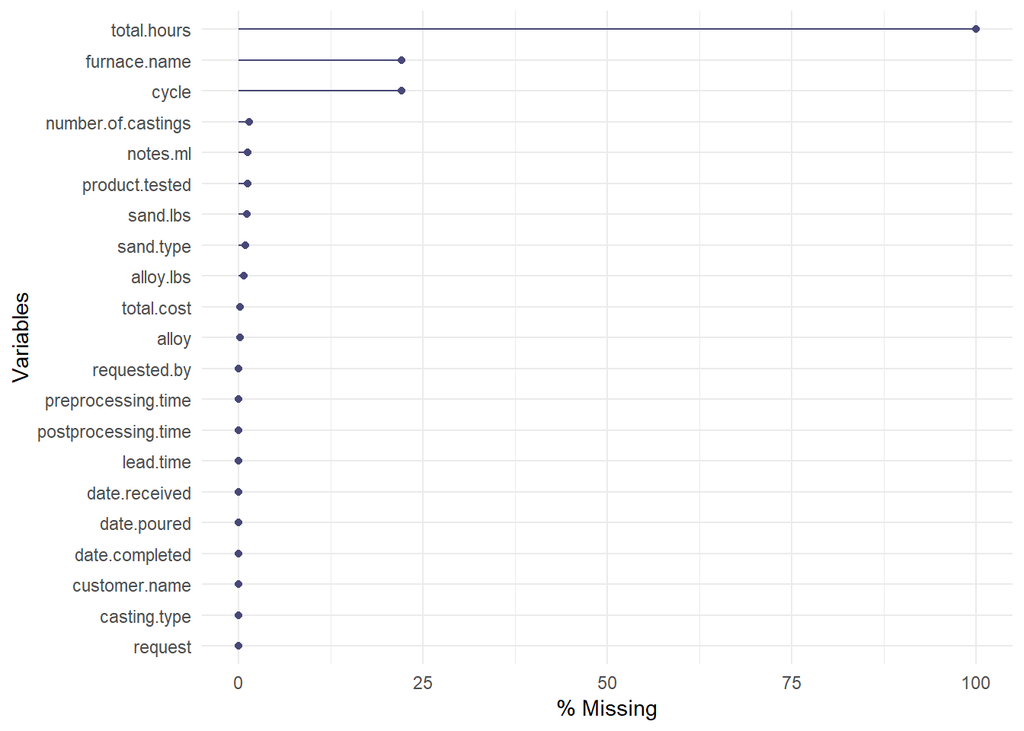

```r
################################
y <- x %>%
  select(request,
         date.received,
         date.poured,
         date.completed,
         requested.by,
         customer.name,
         product.tested,
         casting.type,
         number.of.castings,
         alloy,
         alloy.lbs,
         sand.type,
         sand.lbs,
         total.hours,
         total.cost,
         preprocessing.time,
         postprocessing.time,
         lead.time,
         furnace.name,
         cycle,
         notes.ml) %>%
  mutate(requested.by=as.factor(requested.by)) %>%
  mutate(customer.name=as.factor(customer.name)) %>%
  mutate(product.tested=as.factor(product.tested)) %>%
  mutate(casting.type=as.factor(casting.type)) %>%
  mutate(alloy=as.factor(alloy)) %>%
  mutate(sand.type=as.factor(sand.type)) %>%
  mutate(furnace.name=as.factor(furnace.name))

gg_miss_var(y, show_pct = T)
```

```r
glimpse(y)
```

```
## Observations: 3,631
## Variables: 21
## $ request             <dbl> 1, 2, 3, 4, 5, 6, 7, 8, 9, 10, 11, 12, 13,...
## $ date.received       <date> 1999-01-04, 1999-01-04, 1999-01-04, 1999-...
## $ date.poured         <date> 1999-01-05, 1999-01-06, 1999-01-07, 1999-...
## $ date.completed      <date> 1999-01-13, 1999-01-13, 1999-01-13, 1999-...
## $ requested.by        <fct> clingermanm, clingerman m, clingerman m, c...
## $ customer.name       <fct> TS&D, TS&D, TS&D, TS&D, BRILLION, K O STEE...
## $ product.tested      <fct> ISOCURE, ISOCURE, ISOCURE, ISOCURE, ISOCUR...
## $ casting.type        <fct> stepcone, stepcone, erosion wedge, erosion...
## $ number.of.castings  <dbl> 8, 8, 8, 8, 3, 1, 8, 10, 8, 4, 10, 8, 2, 1...
## $ alloy               <fct> grey iron, grey iron, grey iron, grey iron...
## $ alloy.lbs           <dbl> 250, 250, 600, 600, 90, 90, 160, 30, 20, 1...
## $ sand.type           <fct> technisand 1l-5w, technisand 1l-5w, techni...
## $ sand.lbs            <dbl> 840, 840, 1680, 1680, 270, 210, 640, 240, ...
## $ total.hours         <lgl> NA, NA, NA, NA, NA, NA, NA, NA, NA, NA, NA...
## $ total.cost          <dbl> 1300, 1300, 2210, 2210, 862, 715, 2080, 84...
## $ preprocessing.time  <dbl> 1, 2, 3, 4, 5, 2, 1, 3, 2, 7, 1, 1, 4, 1, ...
## $ postprocessing.time <dbl> 8, 7, 6, 5, 1, 2, 8, 1, 1, 4, 1, 3, -2, 5,...
## $ lead.time           <dbl> 9, 9, 9, 9, 6, 4, 9, 4, 3, 11, 2, 4, 2, 6,...
## $ furnace.name        <fct> regenia, regenia, regenia, regenia, regeni...
## $ cycle               <dbl> 1, 2, 3, 4, 5, 6, 7, NA, NA, NA, NA, NA, N...
## $ notes.ml            <chr> "TEST NEW BASE RESIN WITH STEPCONE CASTING...
```

```r
# export to xls
write.xlsx(y, file=paste0(getwd(),"/data/cleanedMAL.xlsx"), sheetName="Sheet1",
           col.names=TRUE, row.names=TRUE, append=FALSE)
```

# Analysis

Now we need to figure out what to do with the data. First we can try some simple EDA with what variables we have, then get into analysis more focused on furnace life.

## EDA

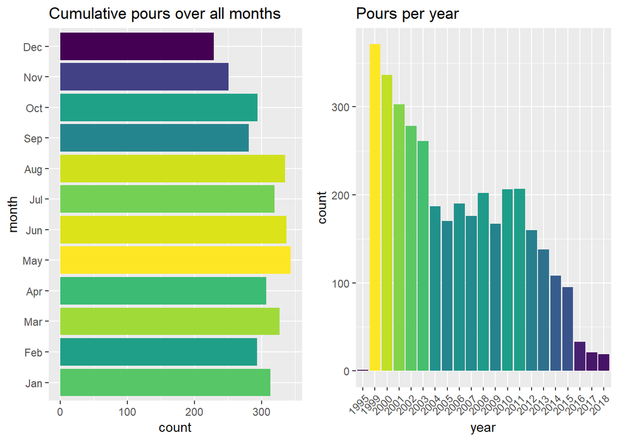

```r
# Histogram of pours per month
g1 <- y %>%
  mutate(month=as.factor(substring(months.Date(x$date.poured),1,3))) %>%
  ggplot(aes(x=month,fill=..count..))+
  geom_histogram(stat="count")+
  scale_x_discrete(limits=c("Jan","Feb","Mar","Apr","May","Jun",
                            "Jul","Aug","Sep","Oct","Nov","Dec"))+
  ggtitle("Cumulative pours over all months")+
  scale_fill_viridis()+
  theme(legend.position = "none")+
  coord_flip()

# Histogram of pours per year
g2 <- y %>%
  mutate(year=as.factor(substring(x$date.poured,1,4))) %>%
  filter(!is.na(year)) %>%
  ggplot(aes(x=year,fill=..count..))+
  geom_histogram(stat="count")+
  ggtitle("Pours per year")+
  scale_fill_viridis()+
  theme(legend.position = "none")+
  theme(axis.text.x = element_text(angle=45,hjust=1))

grid.arrange(g1,g2,ncol=2)
```

Faceting number of pours over the years gives a little more insight as to when pours were occuring.

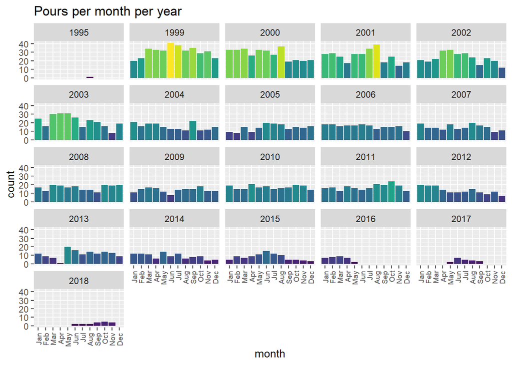

```r
# Pours per month faceted by year
y %>%
  mutate(month=as.factor(substring(months.Date(x$date.poured),1,3))) %>%
  mutate(year=as.factor(substring(x$date.poured,1,4))) %>%
  filter(!is.na(year)) %>%
  ggplot(aes(x=month,fill=..count..))+
  geom_histogram(stat="count")+
  scale_x_discrete(limits=c("Jan","Feb","Mar","Apr","May","Jun",
                            "Jul","Aug","Sep","Oct","Nov","Dec"))+
  ggtitle("Pours per month per year")+
  scale_fill_viridis()+
  theme(legend.position = "none")+
  theme(axis.text.x = element_text(angle=90,hjust=1,vjust=0.5,size=7))+
  facet_wrap(year~.)
```

## Furnace life

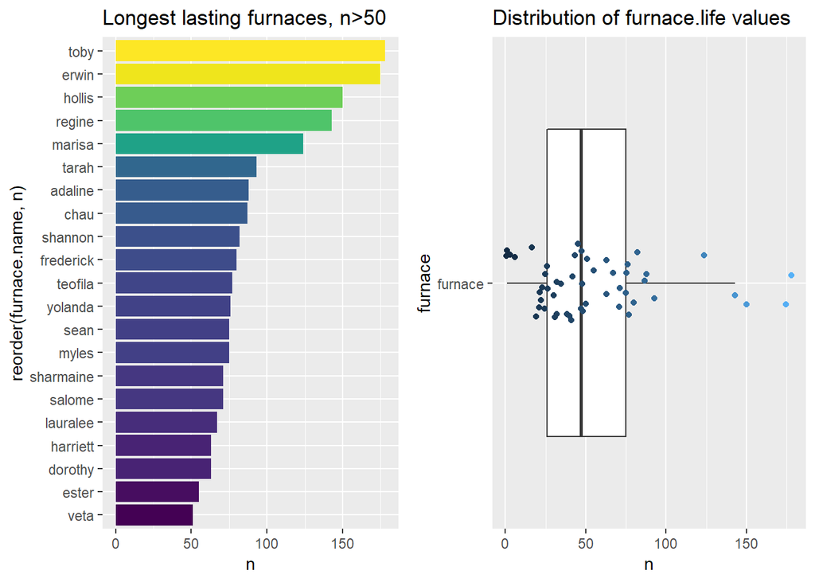

```r
# barplot of longest lasting furnaces
p1 <- y %>%
  filter(!is.na(furnace.name)) %>%
  mutate(furnace.name=as.factor(furnace.name)) %>%
  count(furnace.name) %>%
  # arrange(desc(n)) %>%
  filter(n>50) %>%
  ggplot(aes(x=reorder(furnace.name,n),y=n,fill=n))+
  geom_bar(stat="identity")+
  coord_flip()+
  scale_fill_viridis()+
  theme(legend.position = "none")+
  ggtitle("Longest lasting furnaces, n>50")

# boxplot of furnace life
p2 <- y %>%
  filter(!is.na(furnace.name)) %>%
  mutate(furnace.name=as.factor(furnace.name)) %>%
  count(furnace.name) %>%
  select(-furnace.name) %>%
  mutate(furnace = as.factor("furnace")) %>%
  ggplot(aes(y=n,x=furnace))+
  geom_boxplot(outlier.shape = NA,
               position=position_dodge(width=.9))+
  geom_jitter(aes(color=n),width=.1)+
  coord_flip()+
  theme(legend.position = "none")+
  ggtitle("Distribution of furnace.life values")

grid.arrange(p1,p2,nrow=1)
```